# Democracy and Development

## A Better Package: estimatr

```r
pacman::p_load(estimatr)
# cluster-robust SEs + efficient FE
mod_robust <- lm_robust(polity4 ~ lag_dem + lag_income,
  fixed_effects = country + year,
  clusters = country, data = d)
modelsummary::modelsummary(mod_robust, stars = TRUE,
  coef_omit = "Intercept",
  gof_omit = "AIC|BIC|Log.Lik|F|R2")
```

[output not shown]

## Visualizing FE in Our Data

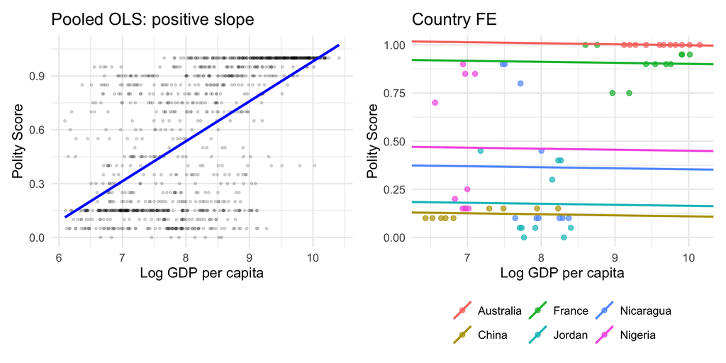

## Why Are Rich Countries Democratic?

> *“These results naturally raise the following important question: why is there a cross-sectional correlation between income and democracy? In other words, why are rich countries democratic today?”*

## The Authors’ Answer

> *“At a statistical level, the answer is clear: even though there is no relationship between changes in income and democracy in the postwar era or over the past 100 years or so, there is a positive association over the past 500 years.”*

## Historical Roots of the Correlation

> *“In particular, for the whole world sample, the positive association is considerably weakened when we control for date of independence, early constraints on the executive, and religion.”*

## Do We Buy It?

- Acemoglu et al.’s claim: the income-democracy correlation reflects deep historical divergence, not a modern causal effect of income on democracy
- What do you think? Is this convincing?
- What would it take to change your mind?

## Summing up

- Good theoretical reasons to think democracy is causally related to development
- Most extant work focuses on micro, sub-national dynamics
- Fixed effects control for **time-invariant** unobserved confounders
- If confounders change over time, FE cannot help

# Appendix: Instrumental Variables

## Strategy 2: Instrumental Variables

> *“Our second strategy is to use instrumental-variables (IV) regressions to estimate the impact of income on democracy”*
- When FE is not enough (time-varying confounders remain), IV provides another approach
- Core idea: find a variable Z that shifts income but has no direct effect on democracy

## IV Intuition

- We need a variable Z (the “instrument”) that:
  1. Is correlated with income (relevance)
  2. Affects democracy *only* through income (exclusion restriction)
- Z isolates the part of income variation that is “as-if random”
- Acemoglu et al. use **trade-weighted world income** as instrument: global economic shocks shift a country’s income but arguably do not directly cause democratization

## The Exclusion Restriction

- The critical assumption: Z affects democracy ONLY through income

$$Z \rightarrow Income \rightarrow Democracy$$

- There must be **no direct arrow** from Z to Democracy
- This is untestable; it must be argued on substantive grounds
- If the exclusion restriction fails, IV estimates are biased

## IV in Acemoglu et al.

- Instrument: trade-weighted world income
- Logic: when your trading partners get richer, your income goes up (relevance)
- Exclusion: your partners’ income growth does not directly change your political institutions
- Result: IV estimates also show no causal effect of income on democracy

## Limitations of IV

- Exclusion restriction is never testable
- Results depend heavily on instrument choice
- IV estimates a *local* effect (for observations affected by the instrument)
- Combined with FE evidence, strengthens the case against modernization theory